# 776_Project1

MATEO BANDALA-JACQUES

2024-08-29

```r
#Load the require packages
library(tidyverse, quietly = TRUE)
library(tidytuesdayR)
library(here)
#Create a repository to save the data locally
if (!file.exists(here("data", "chocolate.RDS"))) {
    url_csv <- "https://raw.githubusercontent.com/rfordatascience/tidytuesday/master/data/2022/2022-01-18/chocolate.csv"
    chocolate <- readr::read_csv(url_csv)

    # save the file to RDS objects
    saveRDS(chocolate, file = here("data", "chocolate.RDS"))
}

#load the data
chocolate <- readRDS(here("data", "chocolate.RDS"))

#Look at the data
as_tibble(chocolate)
```

```
## # A tibble: 2,530 × 10
##      ref company_manufacturer company_location review_date
##    <dbl> <chr>                <chr>                  <dbl>
##  1  2454 5150                 U.S.A.                  2019
##  2  2458 5150                 U.S.A.                  2019
##  3  2454 5150                 U.S.A.                  2019
##  4  2542 5150                 U.S.A.                  2021
##  5  2546 5150                 U.S.A.                  2021
##  6  2546 5150                 U.S.A.                  2021
##  7  2542 5150                 U.S.A.                  2021
##  8   797 A. Morin             France                  2012
##  9   797 A. Morin             France                  2012
## 10  1011 A. Morin             France                  2013
## # ℹ 2,520 more rows
## # ℹ 6 more variables: country_of_bean_origin <chr>,
## #   specific_bean_origin_or_bar_name <chr>, cocoa_percent <chr>,
## #   ingredients <chr>, most_memorable_characteristics <chr>, rating <dbl>
```

```r
#glimpse at the data
glimpse(chocolate)
```

```
## Rows: 2,530
## Columns: 10
## $ ref                              <dbl> 2454, 2458, 2454, 2542, 2546, 2546, 2…
## $ company_manufacturer             <chr> "5150", "5150", "5150", "5150", "5150…
## $ company_location                 <chr> "U.S.A.", "U.S.A.", "U.S.A.", "U.S.A.…
## $ review_date                      <dbl> 2019, 2019, 2019, 2021, 2021, 2021, 2…
## $ country_of_bean_origin           <chr> "Tanzania", "Dominican Republic", "Ma…
## $ specific_bean_origin_or_bar_name <chr> "Kokoa Kamili, batch 1", "Zorzal, bat…
## $ cocoa_percent                    <chr> "76%", "76%", "76%", "68%", "72%", "8…
## $ ingredients                      <chr> "3- B,S,C", "3- B,S,C", "3- B,S,C", "…
## $ most_memorable_characteristics   <chr> "rich cocoa, fatty, bready", "cocoa, …
## $ rating                           <dbl> 3.25, 3.50, 3.75, 3.00, 3.00, 3.25, 3…
```

## *Part 1: Explore the data*

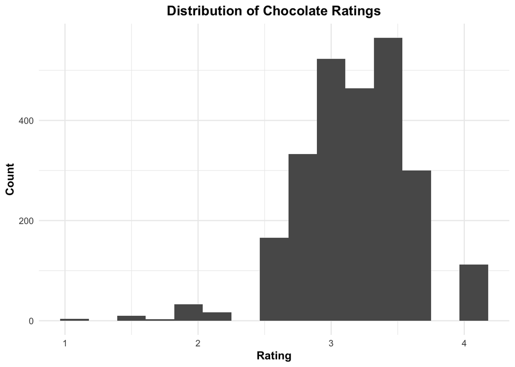

```r
#Make a histogram of the rating scores

chocolate %>%
  ggplot(aes(x=rating)) +
  geom_histogram(bins = 15) +
  labs(
    title = "Distribution of Chocolate Ratings",
    x = "Rating",
    y = "Count"
  ) +
  theme_minimal() +
  theme(
    plot.title = element_text(hjust = 0.5, face = "bold"),
    axis.title = element_text(face = "bold")
  )
```

2.- Consider the countries where the beans originated from. How many reviews come from each country of bean origin?

```r
#Consider the countries where the beans originated from.

#Table
table(chocolate$country_of_bean_origin)
```

```
##
##             Australia                Belize                 Blend
##                     3                    76                   156
##               Bolivia                Brazil                 Burma
##                    80                    78                     1
##              Cameroon                 China              Colombia
##                     3                     1                    79
##                 Congo            Costa Rica                  Cuba
##                    11                    43                    12
##    Dominican Republic              DR Congo               Ecuador
##                   226                     1                   219
##           El Salvador                  Fiji                 Gabon
##                     6                    16                     1
##                 Ghana               Grenada             Guatemala
##                    41                    19                    62
##                 Haiti              Honduras                 India
##                    30                    25                    35
##             Indonesia           Ivory Coast               Jamaica
##                    20                     7                    24
##               Liberia            Madagascar              Malaysia
##                     3                   177                     8
##            Martinique                Mexico             Nicaragua
##                     1                    55                   100
##               Nigeria                Panama      Papua New Guinea
##                     3                     9                    50
##                  Peru           Philippines              Principe
##                   244                    24                     1
##           Puerto Rico                 Samoa              Sao Tome
##                     7                     3                    14
##   Sao Tome & Principe          Sierra Leone       Solomon Islands
##                     2                     4                    10
##             Sri Lanka             St. Lucia St.Vincent-Grenadines
##                     2                    10                     1
##              Sulawesi               Sumatra              Suriname
##                     1                     1                     1
##                Taiwan              Tanzania              Thailand
##                     2                    79                     5
##                Tobago                  Togo              Trinidad
##                     2                     3                    42
##                U.S.A.                Uganda               Vanuatu
##                    33                    19                    13
##             Venezuela               Vietnam
##                   253                    73
```

```r
#How many reviews come from each country of bean origin?
```

3.- What is average rating scores from reviews of chocolate bars that have Ecuador as country_of_bean_origin in this dataset? For this same set of reviews, also calculate (1) the total number of reviews and (2) the standard deviation of the rating scores. Your answer should be a new data frame with these three summary statistics in three columns. Label the name of these columns mean, sd, and total. Solution: Look at above table

```r
chocolate %>%
  filter(country_of_bean_origin=="Ecuador") %>%
  summarize(mean= mean(rating, na.rm=TRUE),
            sd = sd(rating, na.rm=TRUE),
            total=n())
```

```
## # A tibble: 1 × 3
##    mean    sd total
##   <dbl> <dbl> <int>
## 1  3.16 0.512   219
```

Solution: Please see above tibbles.

4.- Which company (name) makes the best chocolate (or has the highest ratings on average) with beans from Ecuador?

```r
chocolate %>%
  filter(country_of_bean_origin=="Ecuador") %>%
  group_by(company_manufacturer) %>%
  summarize(mean=mean(rating, na.rm=TRUE)) %>%
  arrange(desc(mean))
```

```
## # A tibble: 136 × 2
##    company_manufacturer    mean
##    <chr>                  <dbl>
##  1 Amano                   4
##  2 Benoit Nihant           4
##  3 Beschle (Felchlin)      4
##  4 Durci                   4
##  5 Smooth Chocolator, The  4
##  6 Domori                  3.88
##  7 A. Morin                3.75
##  8 Cacao Sampaka           3.75
##  9 Foundry                 3.75
## 10 Goodnow Farms           3.75
## # ℹ 126 more rows
```

Solution: Amano, Benoit Nihant, Beschle, Durci and the Smooth Chocolator all have the highest average rating, at 4.0

5.- Calculate the average rating across all country of origins for beans. Which top 3 countries (for bean origin) have the highest ratings on average?

```r
chocolate %>%
  group_by(country_of_bean_origin) %>%
  summarise(mean_rating = mean(rating, na.rm=TRUE)) %>%
  arrange(desc(mean_rating))
```

```
## # A tibble: 62 × 2
##    country_of_bean_origin mean_rating
##    <chr>                        <dbl>
##  1 Tobago                        3.62
##  2 China                         3.5
##  3 Sao Tome & Principe           3.5
##  4 Solomon Islands               3.45
##  5 Congo                         3.32
##  6 Thailand                      3.3
##  7 Cuba                          3.29
##  8 Vietnam                       3.29
##  9 Papua New Guinea              3.28
## 10 Madagascar                    3.27
## # ℹ 52 more rows
```

Solution: Tobago, China and Sao Tome & Principe

6.- Following up on the previous problem, now remove any countries of bean origins that have less than 10 chocolate bar reviews. Now, which top 3 countries have the highest ratings on average?

```r
chocolate %>%
  group_by(country_of_bean_origin) %>%
  filter(n()>=10)%>%
  summarise(mean_rating = mean(rating, na.rm=TRUE), n=n()) %>%
  arrange(desc(mean_rating))
```

```
## # A tibble: 35 × 3
##    country_of_bean_origin mean_rating     n
##    <chr>                        <dbl> <int>
##  1 Solomon Islands               3.45    10
##  2 Congo                         3.32    11
##  3 Cuba                          3.29    12
##  4 Vietnam                       3.29    73
##  5 Papua New Guinea              3.28    50
##  6 Madagascar                    3.27   177
##  7 Haiti                         3.27    30
##  8 Brazil                        3.26    78
##  9 Guatemala                     3.26    62
## 10 Nicaragua                     3.26   100
## # ℹ 25 more rows
```

Solution: It is now Solomon Islands, Congo and Cuba

7.- For this last part, let’s explore the relationship between percent chocolate and ratings.

```r
# 1Identify the countries of bean origin with at least 50 reviews. Remove reviews from countries are not in this list.

chocolate <- chocolate %>%
  group_by(country_of_bean_origin) %>%
  filter(n()>=50) %>%
  ungroup()



# Using the variable describing the chocolate percentage for each review, create a new column that groups chocolate  percentages into one of four groups: (i) <60%, (ii) >=60 to <70%, (iii) >=70 to <90%, and (iii) >=90% (Hint check out the substr() function in base R and the case_when() function from dplyr – see example below).

chocolate <- chocolate %>%
  mutate(cocoa_percent2 = as.numeric(gsub("%", "", cocoa_percent))) %>%
  mutate(cocoa_percent_cat = case_when(
    cocoa_percent2 <60 ~ "i",
    cocoa_percent2 >=60 & cocoa_percent2 <70 ~ "ii",
    cocoa_percent2>= 70 & cocoa_percent2 <90 ~ "iii",
    cocoa_percent2>=90 ~ "iv",
    .default=NA
  ))


chocolate %>%
  select(cocoa_percent, cocoa_percent2, cocoa_percent_cat) %>%
  slice_sample(n=25)
```

```
## # A tibble: 25 × 3
##    cocoa_percent cocoa_percent2 cocoa_percent_cat
##    <chr>                  <dbl> <chr>
##  1 70%                       70 iii
##  2 73%                       73 iii
##  3 70%                       70 iii
##  4 70%                       70 iii
##  5 100%                     100 iv
##  6 71%                       71 iii
##  7 73%                       73 iii
##  8 75%                       75 iii
##  9 70%                       70 iii
## 10 70%                       70 iii
## # ℹ 15 more rows
```

```r
table(chocolate$cocoa_percent_cat)
```

```
##
##    i   ii  iii   iv
##   23  270 1682   32
```

```r
#Using the new column described in #2, re-order the factor levels (if needed) to be starting with the smallest percentage group and increasing to the largest percentage group (Hint check out the fct_relevel() function from forcats).

chocolate$cocoa_percent_cat <- factor(chocolate$cocoa_percent_cat, levels = c("i", "ii", "iii", "iv"))


levels(chocolate$cocoa_percent_cat)
```

```
## [1] "i"   "ii"  "iii" "iv"
```

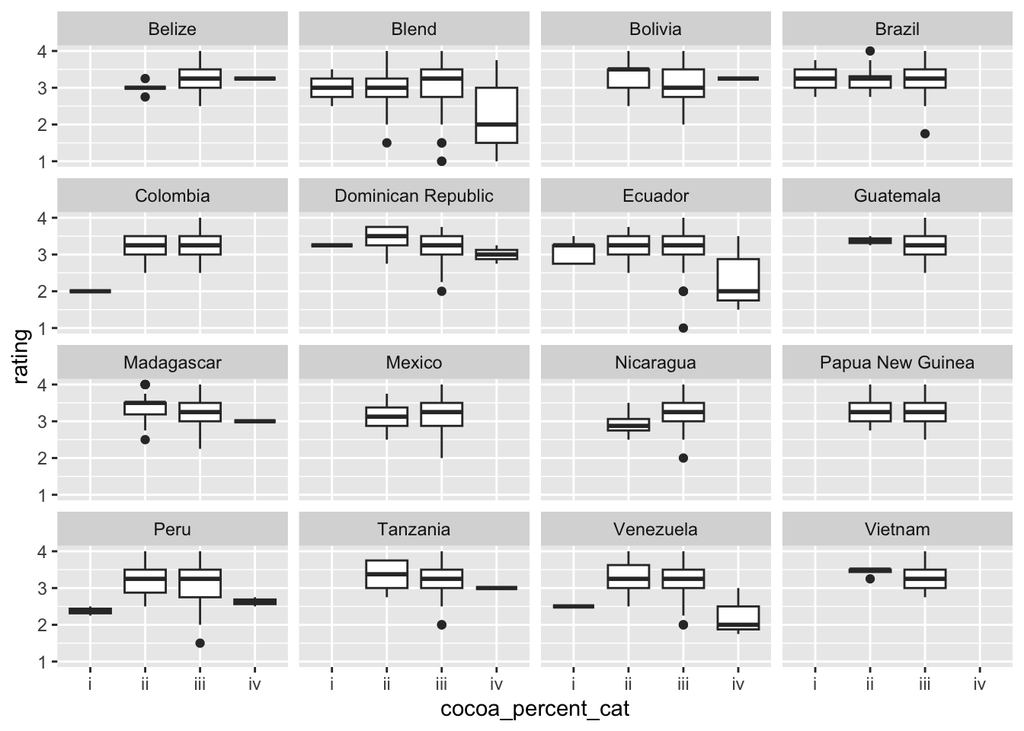

```r
#For each country, make a set of four side-by-side boxplots plotting the groups on the x-axis and the ratings on the y-axis. These plots should be faceted by country.


chocolate %>%
  ggplot(aes(x=cocoa_percent_cat, y=rating)) +
  geom_boxplot() +
  facet_wrap(~country_of_bean_origin)
```

```r
chocolate %>% group_by(cocoa_percent_cat) %>% summarise(mean=mean(rating,na.rm=TRUE))
```

```
## # A tibble: 4 × 2
##   cocoa_percent_cat  mean
##   <fct>             <dbl>
## 1 i                  2.96
## 2 ii                 3.25
## 3 iii                3.22
## 4 iv                 2.49
```

```r
#On average, which category of chocolate percentage is most highly rated? Do these countries mostly agree or are there disagreements?
```

## *Part 2: Join two datasets together*

2.1 Use this dataset it to create a new column called continent in our chocolate dataset that contains the continent name for each review where the country of bean origin is.

```r
library(gapminder)
head(gapminder)
```

```
## # A tibble: 6 × 6
##   country     continent  year lifeExp      pop gdpPercap
##   <fct>       <fct>     <int>   <dbl>    <int>     <dbl>
## 1 Afghanistan Asia       1952    28.8  8425333      779.
## 2 Afghanistan Asia       1957    30.3  9240934      821.
## 3 Afghanistan Asia       1962    32.0 10267083      853.
## 4 Afghanistan Asia       1967    34.0 11537966      836.
## 5 Afghanistan Asia       1972    36.1 13079460      740.
## 6 Afghanistan Asia       1977    38.4 14880372      786.
```

```r
chocolate <- readRDS(here("data", "chocolate.RDS"))

gapminder <- gapminder %>%
  select(country, continent) %>%
  group_by(country) %>%
  slice_head() %>%
  ungroup()

chocolate <- left_join(chocolate, gapminder, by=c("country_of_bean_origin" = "country"))


table(chocolate$continent)
```

```
##
##   Africa Americas     Asia   Europe  Oceania
##      333     1552      170        0        3
```

2.2 Only keep reviews that have reviews from countries of bean origin with at least 10 reviews.

```r
chocolate <- chocolate %>%
  group_by(country_of_bean_origin) %>%
  filter(n()>=10) %>%
  ungroup()
```

2.3 Also, remove the country of bean origin named “Blend”.

```r
chocolate <- chocolate %>%
  filter(country_of_bean_origin!="Blend")
```

Make a set of violin plots with ratings on the y-axis and continents on the x-axis. Hint:

Check to see if there are any NAs in the new column. If there are any NAs, add the continent name for each row.

```r
chocolate %>%
  filter(is.na(continent)) %>%
  group_by(country_of_bean_origin) %>%
  summarise(n=n())
```

```
## # A tibble: 11 × 2
##    country_of_bean_origin     n
##    <chr>                  <int>
##  1 Belize                    76
##  2 Congo                     11
##  3 Fiji                      16
##  4 Grenada                   19
##  5 Papua New Guinea          50
##  6 Sao Tome                  14
##  7 Solomon Islands           10
##  8 St. Lucia                 10
##  9 Trinidad                  42
## 10 U.S.A.                    33
## 11 Vanuatu                   13
```

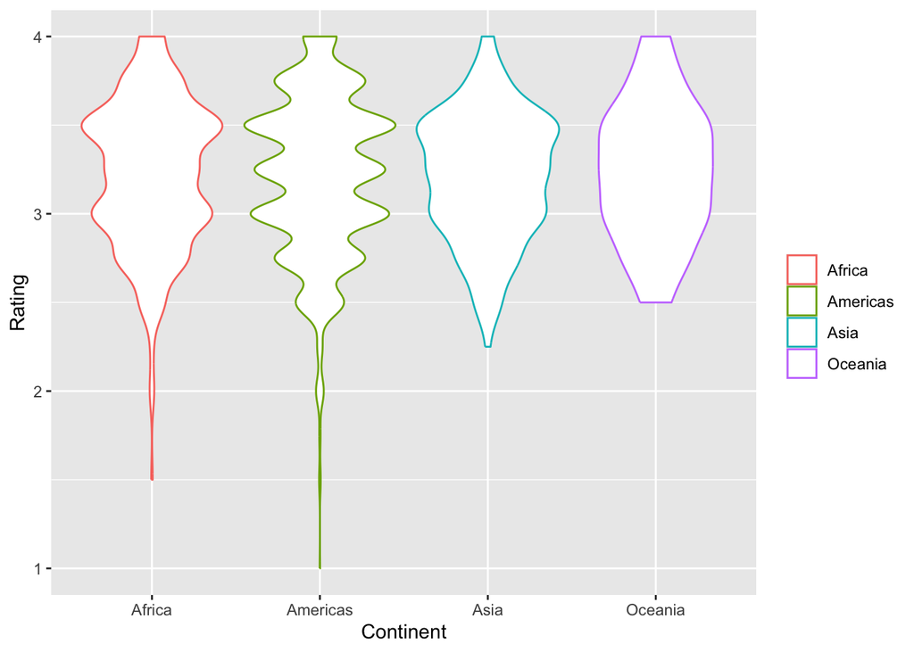

```r
Americas <- c("Belize", "Grenada", "St. Lucia", "Trinidad", "U.S.A." )
Africa <- c("Congo", "Sao Tome")
Oceania <- c("Fiji", "Papua New Guinea", "Solomon Islands", "Vanuatu")


chocolate$continent[chocolate$country_of_bean_origin %in% Americas] <- "Americas"
chocolate$continent[chocolate$country_of_bean_origin %in% Africa] <- "Africa"
chocolate$continent[chocolate$country_of_bean_origin %in% Oceania] <- "Oceania"



chocolate %>%
  ggplot(aes(x=continent, y=rating, color=continent))+
  geom_violin() +
  labs(x="Continent", y="Rating", color="")
```

## **Part 3: Convert wide data into long data**

We are going to create a set of features for us to plot over time. Use the functions in dplyr and tidyr to perform the following steps to the chocolate dataset:

1.- Create a new set of columns titled beans, sugar, cocoa_butter, vanilla, letchin, and salt that contain a 1 or 0 representing whether or not that review for the chocolate bar contained that ingredient (1) or not (0).

```r
chocolate <- readRDS(here("data", "chocolate.RDS"))


chocolate$beans <- ifelse(grepl("B", chocolate$ingredients),1,0)
chocolate$sugar <- ifelse(grepl("S", chocolate$ingredients),1,0)
chocolate$cocoa_butter <- ifelse(grepl("C", chocolate$ingredients),1,0)
chocolate$vanilla <- ifelse(grepl("V", chocolate$ingredients),1,0)
chocolate$lecithin <- ifelse(grepl("L", chocolate$ingredients),1,0)
chocolate$salt <- ifelse(grepl("Sa", chocolate$ingredients),1,0)


chocolate %>%
  select(ingredients, beans, sugar, cocoa_butter, vanilla, lecithin, salt) %>%
  slice_sample(n=50)
```

```
## # A tibble: 50 × 7
##    ingredients beans sugar cocoa_butter vanilla lecithin  salt
##    <chr>       <dbl> <dbl>        <dbl>   <dbl>    <dbl> <dbl>
##  1 2- B,S*         1     1            0       0        0     0
##  2 2- B,S          1     1            0       0        0     0
##  3 2- B,S          1     1            0       0        0     0
##  4 3- B,S,C        1     1            1       0        0     0
##  5 3- B,S,C        1     1            1       0        0     0
##  6 3- B,S,C        1     1            1       0        0     0
##  7 2- B,S          1     1            0       0        0     0
##  8 2- B,S          1     1            0       0        0     0
##  9 4- B,S,C,L      1     1            1       0        1     0
## 10 2- B,S          1     1            0       0        0     0
## # ℹ 40 more rows
```

```r
#looks good!
```

3.2 Create a new set of columns titled char_cocoa, char_sweet, char_nutty, char_creamy, char_roasty, char_earthy that contain a 1 or 0 representing whether or not that the most memorable characteristic for the chocolate bar had that word (1) or not (0). For example, if the word “sweet” appears in the most_memorable_characteristics, then record a 1, otherwise a 0 for that review in the char_sweet column (Hint: check out str_detect() from the stringr package).

```r
chocolate$char_cocoa <- str_detect(chocolate$most_memorable_characteristics, "cocoa")
chocolate$char_sweet <- str_detect(chocolate$most_memorable_characteristics, "sweet")
chocolate$char_nutty <- str_detect(chocolate$most_memorable_characteristics, "nutty")
chocolate$char_creamy <- str_detect(chocolate$most_memorable_characteristics, "creamy")
chocolate$char_roasty <- str_detect(chocolate$most_memorable_characteristics, "roasty")
chocolate$char_earthy <- str_detect(chocolate$most_memorable_characteristics, "earthy")


chocolate$char_cocoa <- ifelse(chocolate$char_cocoa==TRUE,1,0)
chocolate$char_sweet <- ifelse(chocolate$char_sweet==TRUE,1,0)
chocolate$char_nutty <- ifelse(chocolate$char_nutty==TRUE,1,0)
chocolate$char_creamy <- ifelse(chocolate$char_creamy==TRUE,1,0)
chocolate$char_roasty <- ifelse(chocolate$char_roasty==TRUE,1,0)
chocolate$char_earthy <- ifelse(chocolate$char_earthy==TRUE,1,0)


chocolate %>%
  select(most_memorable_characteristics, char_cocoa, char_sweet, char_nutty, char_roasty, char_earthy) %>%
  slice_head(n=30)
```

```
## # A tibble: 30 × 6
##    most_memorable_characteristics   char_cocoa char_sweet char_nutty char_roasty
##    <chr>                                 <dbl>      <dbl>      <dbl>       <dbl>
##  1 rich cocoa, fatty, bready                 1          0          0           0
##  2 cocoa, vegetal, savory                    1          0          0           0
##  3 cocoa, blackberry, full body              1          0          0           0
##  4 chewy, off, rubbery                       0          0          0           0
##  5 fatty, earthy, moss, nutty,chal…          0          0          1           0
##  6 mildly bitter, basic cocoa, fat…          1          0          0           0
##  7 milk brownie, macadamia,chewy             0          0          0           0
##  8 vegetal, nutty                            0          0          1           0
##  9 fruity, melon, roasty                     0          0          0           1
## 10 brief fruit note, earthy, nutty           0          0          1           0
## # ℹ 20 more rows
## # ℹ 1 more variable: char_earthy <dbl>
```

For each year (i.e. review_date), calculate the mean value in each new column you created across all reviews for that year. (Hint: If all has gone well thus far, you should have a dataset with 16 rows and 13 columns).

```r
chocolate_summary <- chocolate %>%
  group_by(review_date) %>%
  summarise(
    mean_beans = mean(beans, na.rm = TRUE),
    mean_sugar = mean(sugar, na.rm = TRUE),
    mean_cocoa_butter = mean(cocoa_butter, na.rm = TRUE),
    mean_vanilla = mean(vanilla, na.rm = TRUE),
    mean_lecithin = mean(lecithin, na.rm = TRUE),
    mean_salt = mean(salt, na.rm = TRUE),
    mean_char_cocoa = mean(char_cocoa, na.rm = TRUE),
    mean_char_sweet = mean(char_sweet, na.rm = TRUE),
    mean_char_nutty = mean(char_nutty, na.rm = TRUE),
    mean_char_creamy = mean(char_creamy, na.rm = TRUE),
    mean_char_roasty = mean(char_roasty, na.rm = TRUE),
    mean_char_earthy = mean(char_earthy, na.rm = TRUE)
  )
```

Convert this wide dataset into a long dataset with a new feature and mean_score column.

```r
chocolate_long <- chocolate_summary %>%
  pivot_longer(
    cols = starts_with("mean_"),
    names_to = "feature",
    names_prefix = "mean_",
    values_to = "mean_score")

head(chocolate_long)
```

```
## # A tibble: 6 × 3
##   review_date feature      mean_score
##         <dbl> <chr>             <dbl>
## 1        2006 beans             0.968
## 2        2006 sugar             0.968
## 3        2006 cocoa_butter      0.903
## 4        2006 vanilla           0.694
## 5        2006 lecithin          0.694
## 6        2006 salt              0
```

Solution: See above

## **Part 4: Data visualization**

Use the functions in ggplot2 package to make a scatter plot of the mean_scores (y-axis) over time (x-axis). There should be one plot (facet) for each feature. For full credit, your plot should include:

An overall title for the plot and a subtitle summarizing key trends that you found. Also include a caption in the figure with your name. Both the observed points for the mean_score, but also a smoothed non-linear pattern of the trend All plots should be shown in the one figure There should be an informative x-axis and y-axis label

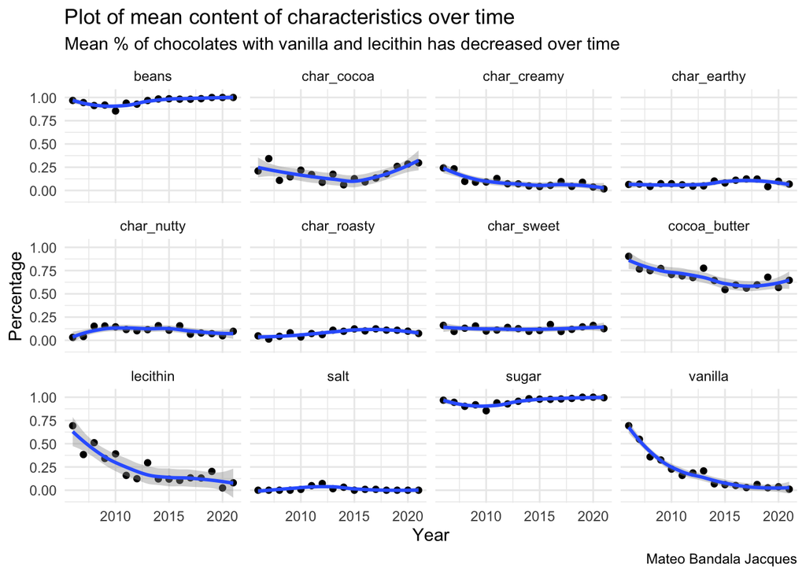

```r
chocolate_long %>%
  ggplot(aes(x=review_date, y=mean_score)) +
  geom_point()+
  geom_smooth()+
  facet_wrap(~feature) +
  ggtitle("Plot of mean content of characteristics over time") +
  labs(subtitle ="Mean % of chocolates with vanilla and lecithin has decreased over time",
       caption = "Mateo Bandala Jacques", x="Year", y="Percentage")+
  theme_minimal()
```

## **Part 5: Make the worst plot you can**

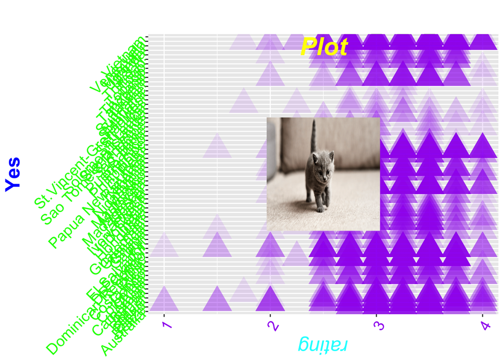

```r
library(png)
library(grid)


cat <- readPNG(here("data", "cat.png"))
cat_fig <- rasterGrob(cat, width = unit(4, "cm"), height = unit(4, "cm"))



ggplot(chocolate, aes(x = country_of_bean_origin, y = rating)) +
  geom_point(size = 10, shape = 17, color = "purple", fill = "yellow", alpha = 0.1) +
  theme(
    axis.title.x = element_text(size = 20, face = "italic", color = "cyan", angle = 180),
    axis.title.y = element_text(size = 20, face = "bold", color = "blue", angle = 90),
    axis.text.x = element_text(size = 15, angle = 60, hjust = 1, color = "purple"),
    axis.text.y = element_text(size = 15, color = "green", angle = 45),
    plot.title = element_text(size = 25, face = "bold.italic", hjust = 0.5, vjust = -5, color = "yellow"),
    legend.position = "top" ) +
  labs(x="Yes") +
  annotation_custom(cat_fig) +
  coord_flip()+
  ggtitle("Plot")
```

Here is how I customized my plot:

- I changed the size and shape of the points, which could be used for emphasis
- I changed the size, face, colour and angle of the X axis, which helps visualize the plot
- I changed the Y axis title, face, and color, for similar reason
- I rotated the X axis text, as in, the countries (this one is actually useful)
- I changed the position of the legend, which may help reduce cluuter
- I added a cute kitten to help with anxiety
- I rotated the plot 90 degrees for clarity

## **Part 6: Make my plot a better plot**

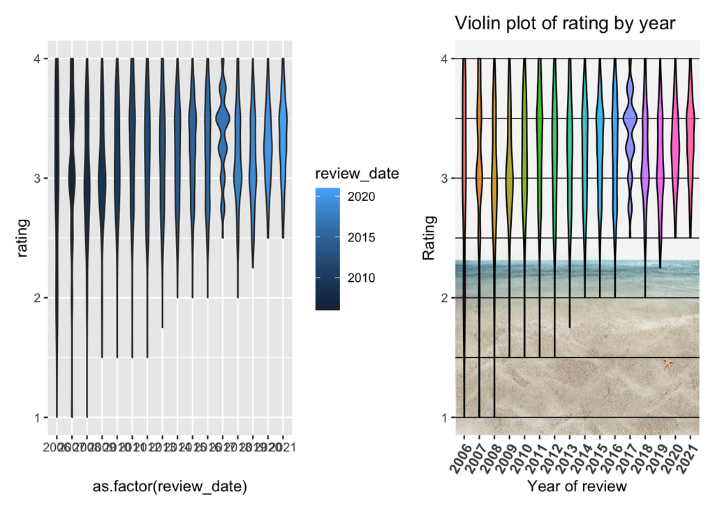

```r
library(patchwork)
library(jpeg)

#Original
a<- chocolate %>%
    ggplot(aes(
        x = as.factor(review_date),
        y = rating,
        fill = review_date
    )) +
    geom_violin()


# Mateo's version

beach <- readJPEG(here("data", "beach2.jpg"))

beach_grob <- rasterGrob(beach,
                              width = unit(1, "npc"),
                              height = unit(1, "npc"), interpolate=TRUE)

b<- chocolate %>%
    ggplot(aes(x = as.factor(review_date), y = rating, fill = as.factor(review_date))) +
  annotation_custom(beach_grob, xmin = -Inf, xmax = Inf, ymin = -Inf, ymax = Inf)  +
  geom_hline(yintercept = seq(1, 4, by = 0.5), color = "black", size = 0.3, linetype = "solid") +
          geom_violin(alpha=0.8, color="black", show.legend = FALSE) +
       labs(x= "Year of review", y="Rating", fill="Review date")+
  theme(axis.text.x = element_text(size = 10, angle = 60, hjust = 1, face="bold")) +
  ggtitle("Violin plot of rating by year")
a + b
```

How I improved the plot:

- I rotated and bolded the X axis ticks
- I changed the names of the X and y axis
- I changed the fill of the violin (this has no purpose other than aesthetics)
- I added thick outlines to each of the plots
- I added a calming tropical beach to the background
- I added a title
- I added black horizontal lines for ease of visualization

```r
library(sessioninfo)

options(width = 120)
```